# Lecture 5: Loops and Related Iterations

Kelly and Gallego

Do you ever find yourself repeating yourself, doing the same thing over and over and over again, redundantly? **R** has a solution for you.

Picture this: You have some information that you’ve collected across different months of the year. Let’s say you’ve counted barnacles on rocks each month, and you have the following dataset (which we’ll create here from scratch):

```r
set.seed(108)
  AreaSampled <- round(runif(1200, min = 1, max = 100), 2)
  Barnacles <- round(rnorm(n = 1200, mean = 1000, sd = 100)*AreaSampled, 0)
  Month <- rep(1:12, each = 100)
  Continent <- sample(c("Africa", "Asia", "Europe", "NAmerica", "SAmerica", "Australia", "Antarctica"), 1200, replace =T)

  myData <- data.frame(AreaSampled, Barnacles, Month, Continent)

  head(myData)
```

```
##   AreaSampled Barnacles Month  Continent
## 1       46.05     39512     1     Africa
## 2       40.99     45973     1  Australia
## 3       35.78     27781     1   SAmerica
## 4       66.77     72985     1 Antarctica
## 5       46.88     46790     1     Africa
## 6        3.29      3488     1  Australia
```

How might you find out about the relationship between barnacles and the area you sampled, and whether that is different during different months of the year or on different continents?

In Excel, you’d spend a day plotting different subsets of data. You’d make many graphs. Your wrist would be tired from using the mouse/trackpad.

With **R**, you can just write a loop: for every month (for example), run a new correlation

```r
  results.vector <- c()                             #create an empty container in which to store results
 for (i in 1:length(unique(myData$Month))){         #set up the loop; for each unique Month...
    x <- myData$AreaSampled[myData$Month == i]      #create a subset of AreaSampled in that Month...
    y <- myData$Barnacles[myData$Month == i]        #create a subset of Barnacles counted in that Month...
  results.vector[i] <- cor(x, y)                    #calculate a correlation with cor(), and store that value
  }

results.vector  #and looking at the results, is there a trend over time?
```

```
##  [1] 0.9759836 0.9775353 0.9807033 0.9821789 0.9810702 0.9822963 0.9850364
##  [8] 0.9819651 0.9729984 0.9748164 0.9812516 0.9839768
```

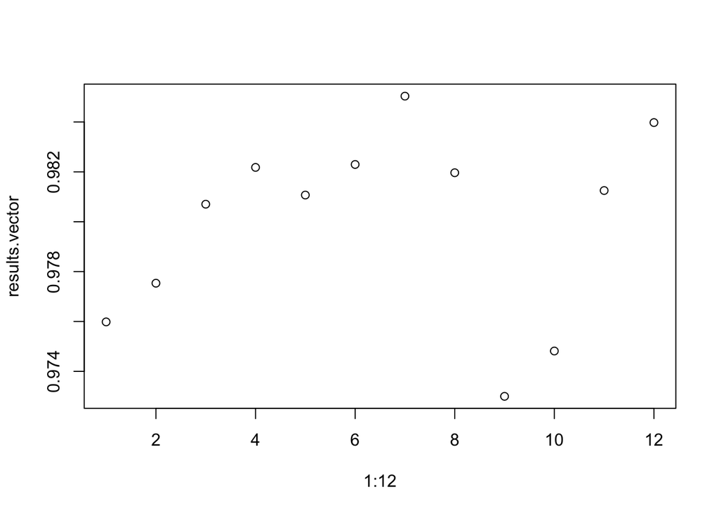

```r
plot(y = results.vector, x = 1:12)  #no, doesn't look like it
```

The basic idea of a *for loop* is to do the same calculation (above, *cor()*) many times, while changing something about the data in each iteration. It can be as simple as:

```r
for(i in 1:5){    #for each value of an iteration variable (here called "i", but it can be anything) between 1 and 5...
  print(i)        #do this thing
}                 #and when you hit the closure bracket, go back and change the iteration variable to the next value in line, and start over.
```

```
## [1] 1
## [1] 2
## [1] 3
## [1] 4
## [1] 5
```

By convention, the *iteration variable* is often called *i* or *j* or *k*, but it can be whatever you want. For example:

```r
for (YARRRR in 1:5){
  print(YARRRR * 10)
}
```

```
## [1] 10
## [1] 20
## [1] 30
## [1] 40
## [1] 50
```

### Quick exercise

```
The function `is.prim(x)` from the package 'schoolmath' returns a logical result (TRUE / FALSE) telling you whether the number `x` is a prime number.

Create a `for` loop that returns a vector telling you whether numbers from 1 to 20 are prime or not, like:

the number 1 is prime - TRUE
.
.
.
the number 4 is prime - FALSE

(Note: the function `paste` allows you to paste together text, numbers, variables...)
```

> And from the *Pirate’s Guide*:

## Creating multiple plots with a loop

> One of the best uses of a loop is to create multiple graphs quickly and easily. Let’s use a loop to create 4 plots representing data from an exam containing 4 questions. The data are represented in a matrix with 100 rows (representing 100 different people), and 4 columns representing scores on the different questions. The data are stored in the `yarrr` package in an object called `examscores`. Here are how the first few rows of the data look

```r
# First few rows of the examscores data
head(examscores)
```

```
##    a  b  c  d
## 1 43 31 68 34
## 2 61 27 56 39
## 3 37 41 74 46
## 4 54 36 62 41
## 5 56 34 82 40
## 6 73 29 79 35
```

> Now, we’ll loop over the columns and create a histogram of the data in each column. First, I’ll set up a 2 x 2 plotting space with `par(mfrow())` (If you haven’t seen `par(mfrow())` before, just know that it allows you to put multiple plots side-by-side). Next, I’ll define the `loop object` as `i`, and the `loop vector` as the integers from 1 to 4 with `1:4`. In the `loop code`, I stored the data in column `i` as a new vector `x`. Finally, I created a histogram of the object `x`!

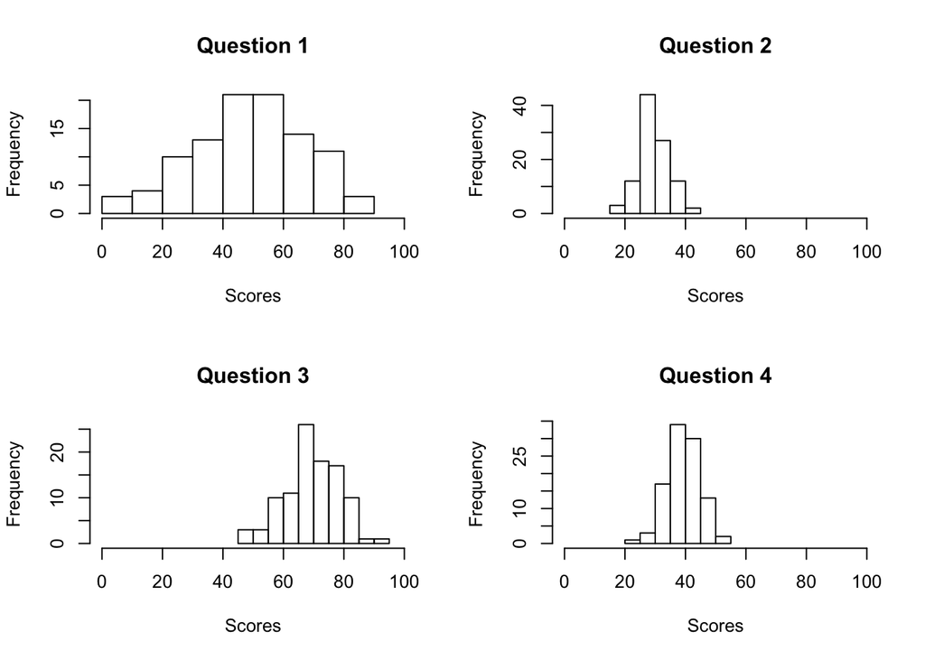

```r
par(mfrow = c(2, 2))  # Set up a 2 x 2 plotting space. Because you set up the space with mfrow, the plotting space will be filled
                      # row by row, left to right. Try out what happens if you use mfcol = c(2,2)

# Create the loop.vector (all the columns)
loop.vector <- 1:4

for (i in loop.vector) { # Loop over loop.vector

  # store data in column.i as x
  x <- examscores[,i]

  # Plot histogram of x
  hist(x,
       main = paste("Question", i),
       xlab = "Scores",
       xlim = c(0, 100))
}
```

That would have been a real pain in Excel.

You can even do loops inside of loops (that is, across multiple variables), although professional programmers frown upon this because it is slow and there are usually better ways to do what you want to do.

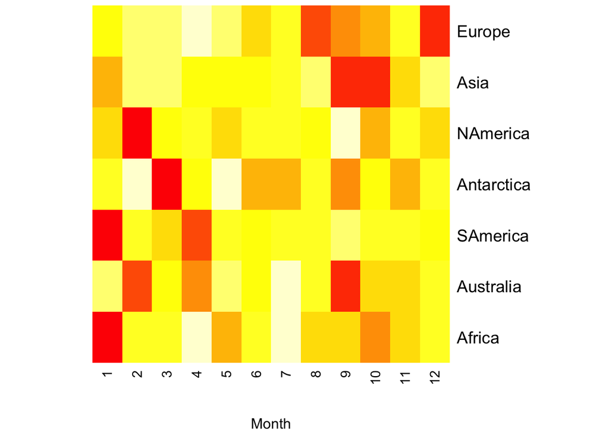

```r
results <- matrix(NA, nrow=length(unique(myData$Continent)), ncol=length(unique(myData$Month)))
  #create a matrix of the correct size

for (i in 1: length(unique(myData$Continent))){  #indexing by name
  for (j in 1:length(unique(myData$Month))){  #indexing by numerical index


    x <- myData$AreaSampled[myData$Continent == unique(myData$Continent)[i] & myData$Month == j]
    y <- myData$Barnacles[myData$Continent == unique(myData$Continent)[i] & myData$Month == j]

    results[i,j] <- cor(x, y)
  }
}

#This gives you a matrix of correlation coefficients; it's easiest to look at that in the form of a heatmap
heatmap(results, Rowv = NA, Colv = NA, labRow = unique(myData$Continent), xlab = "Month")
```

### Quick-ish exercise

```
Remember the `for` loop we asked for in the Problem Set2? Let's get back to it.

Now let's try again the task originally assigned: make a `for` loop that creates an histogram of the departure times from each NY airport to each of the top destinations.
```

```r
library(nycflights13)
 n.flights <- with (flights, table(dest)) # Get the number of flights to each airport
    n.flights <- sort(desc(n.flights))    # Sort it
    top10 <- names (n.flights)[1:10]      # Keep the names of the top10

orgin.airports <- unique(flights$origin)   # The departure airports, conveniently in a vector
```

### `while` - in case you don’t know how many times you want to iterate

One characteristic of the `for` loop is that you need to know what are you iterating over *before* you start the loop. An absurd example would be to calculate the squared value of natural numbers until the square value is greater than 200

```r
i <- 1

while (i^2 < 200) {

  print (paste("The square of", i, "is", i^2))
  i <- i+1

}
```

```
## [1] "The square of 1 is 1"
## [1] "The square of 2 is 4"
## [1] "The square of 3 is 9"
## [1] "The square of 4 is 16"
## [1] "The square of 5 is 25"
## [1] "The square of 6 is 36"
## [1] "The square of 7 is 49"
## [1] "The square of 8 is 64"
## [1] "The square of 9 is 81"
## [1] "The square of 10 is 100"
## [1] "The square of 11 is 121"
## [1] "The square of 12 is 144"
## [1] "The square of 13 is 169"
## [1] "The square of 14 is 196"
```

If you like diagrams, here you have a comparison of `for` and `while` loops

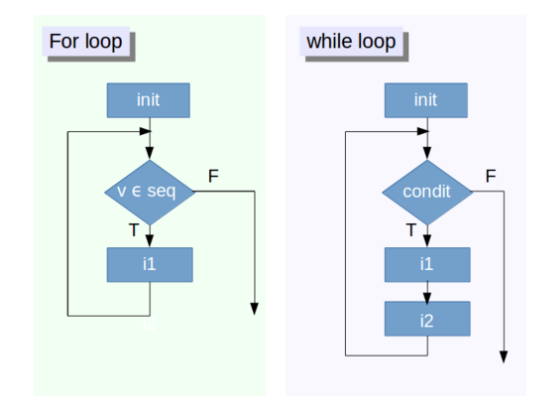

diagrams

The usual structure of a `while` loop includes two sets of commands (i1 and i2 in the diagram). The first one is usually what you actually want the loop to do. The second one sets up the next step in the iteration (in our example, `i <- i + 1`)

# But.. shall we use loops at all?

There are two things to consider:

- when is it worth to write a `for` loop rather than type things out?
- are there other options instead of doing `for` loops?

For the first question, the rule of thumb is to use a `for` loop if you are doing something more than three times. But it also depends on how hard is it to iterate over your data.

For the second question, yes there are. Some of them are **built-in**. And you have been using them already. For example, imagine you have a dataframe and you want to multiply each element of the dataframe by 10.

If you want to, you can do a nested `for` loop to accomplish that task… but it’s definitely not the easiest way.

```r
test.df <-  replicate(10, rnorm(10, mean = 20)) # a matrix of 10 x 10

test.df <- as.data.frame(test.df) # Coerce it into a dataframe

# Doing things the hard way
for ( i in 1:ncol(test.df)){  # Loop over the columns
  for (j in 1:nrow(test.df)){ # Nested loop over rows
    test.df[j,i]<- 10*test.df[j,i]

  }
}

# Using built-in features in R

test.df <- 10 * test.df
```

This is a rather obvious example, but helps us think of different, more efficient ways of facing the tasks we want to do. [^1]

# `apply` and related functions

A way of performing loops without actually writing the loops is using the `apply` and related functions. These functions use:

- An input dataset (upon which you want to perform the action)
- A function, which can either be built-in or customized

And you have some control over the format of the output you obtain (a table, a dataframe, a list…)

The `apply` function works when your input dataset is a dataframe or a matrix, and you want to perform row-wise or column-wise operations.

Let’s imagine you have data from the composition of the intertidal communities on 5 beaches.

```r
Beach.comm <-  round(replicate(10, rnorm(5, mean = 20, sd = 4)),0) # A matrix of 10x5

Beach.comm <- as.data.frame(Beach.comm, row.names = paste("Beach", LETTERS[1:5])) # a dataframe, now with row names

colnames(Beach.comm) <- paste("Species", 1:10) # And also column names
```

Let’s say we want a summary of the abundances by beach first, and similarly by species

```r
apply(Beach.comm, 1, summary) # Summary stats by row (Beach)
```

```
##         Beach A Beach B Beach C Beach D Beach E
## Min.      16.00   11.00   12.00   13.00    9.00
## 1st Qu.   20.25   13.50   17.00   16.50   17.25
## Median    22.00   19.00   19.00   19.00   20.50
## Mean      21.60   18.20   19.50   19.10   19.20
## 3rd Qu.   24.00   22.75   21.75   21.75   23.50
## Max.      24.00   24.00   29.00   25.00   26.00
```

```r
apply(Beach.comm, 2, summary) # Summary stays by column (Species)
```

```
##         Species 1 Species 2 Species 3 Species 4 Species 5 Species 6
## Min.           13      14.0      13.0      17.0      17.0       9.0
## 1st Qu.        21      22.0      17.0      20.0      17.0      15.0
## Median         21      22.0      18.0      20.0      21.0      21.0
## Mean           20      21.4      18.8      20.6      20.8      18.8
## 3rd Qu.        21      24.0      22.0      22.0      24.0      24.0
## Max.           24      25.0      24.0      24.0      25.0      25.0
##         Species 7 Species 8 Species 9 Species 10
## Min.         10.0      12.0        16       11.0
## 1st Qu.      12.0      16.0        18       14.0
## Median       20.0      18.0        23       16.0
## Mean         17.4      18.2        22       17.2
## 3rd Qu.      21.0      22.0        24       19.0
## Max.         24.0      23.0        29       26.0
```

### Quick exercise this time for real

```
Using the Beach.comm dataset, calculate the standard deviation of the counts for each species
```

## `lapply()`

**R** has a way of simplifying loops a bit, because they can get unwieldy.

rather than writing out

`for(i in 1:5){` `print(i)` `}`

you can write the following: `lapply(1:5, print)` which does the same thing as the loop.

Here’s how it works:

*lapply()* is the function from the `apply` *family* of functions that works on “List” - hence the “l”, which is a data structure in **R** that we haven’t talked about yet. Just ignore that for a second.

The code will look like this: `lapply(x = SOME_VECTOR, FUN = SOME_FUNCTION)` , and executing this code just applies the specifed function to each value in the vector, and creates the output in a list. For example:

```r
lapply(myData, mean)  #give the average (mean) of each column in the dataset myData, which we created above.  The fourth column is Continent, so taking its average makes no sense, so the value returned is NA.
```

```
## $AreaSampled
## [1] 49.5183
##
## $Barnacles
## [1] 49250.05
##
## $Month
## [1] 6.5
##
## $Continent
## [1] NA
```

## Saving Computation Time with Large Datasets

Another good example when we shouldn’t use a `for` loop is when we want to subset data, and do an operation on that subset. Although easy to understand when reading / writing the code, it is an inefficient way of facing that problem, and that can lead to long execution times when done with big datasets.

```r
for (i in levels(myData$Continent)){  # For each level of the factor Continent
  print(mean(myData$Barnacles[myData$Continent == i])) # subset the data and calculate the mean barnacle area
}
```

```
## [1] 48985.53
## [1] 46370.02
## [1] 51903.45
## [1] 48950.15
## [1] 49358.75
## [1] 45117.43
## [1] 53973.43
```

And what we are asking the computer to do is

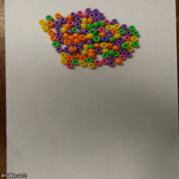

Step_0

An alternative way of doing this - there are many - is to split the dataframe first, and then calculate the mean to each of the subsets

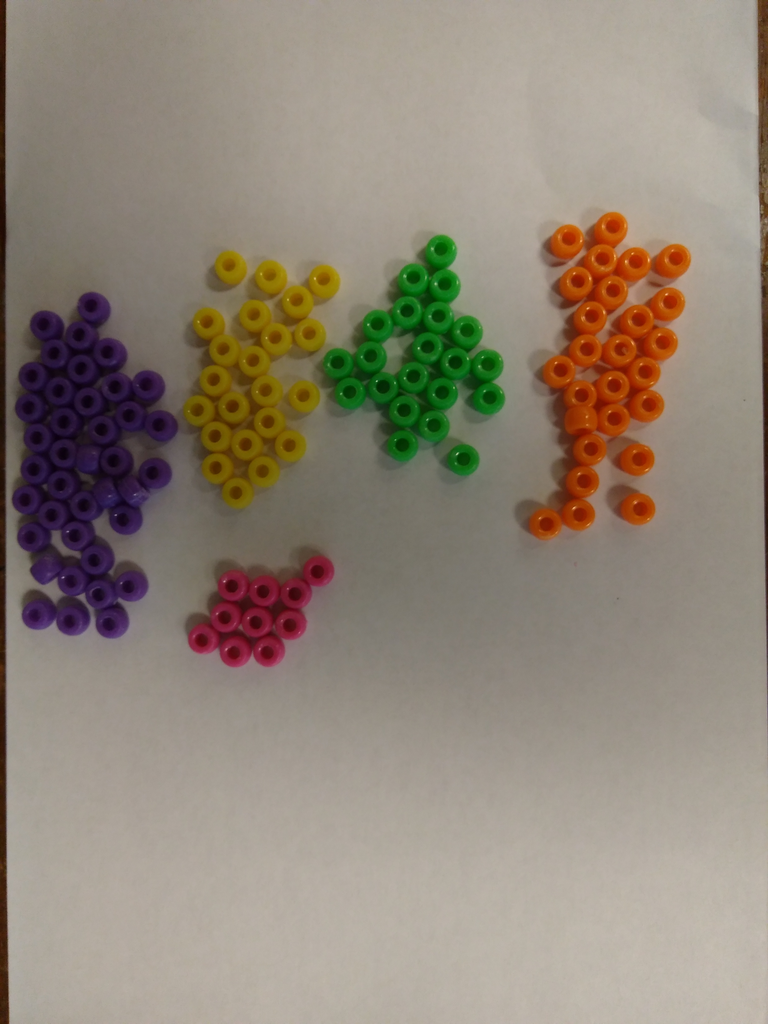

split first

```r
my.data.list <- split(x = myData, f = Continent) # Split a dataframe into a list, each element of the list is one subset

lapply(my.data.list, function(x) mean(x$Barnacles)) # calculate the mean area of barnacle
```

```
## $Africa
## [1] 48985.53
##
## $Antarctica
## [1] 46370.02
##
## $Asia
## [1] 51903.45
##
## $Australia
## [1] 48950.15
##
## $Europe
## [1] 49358.75
##
## $NAmerica
## [1] 45117.43
##
## $SAmerica
## [1] 53973.43
```

## Regarding Lists

Here’s what the *Pirate’s Guide* has to say about Lists. >A list is a special object in R that can store virtually *anything*. You can have a list that contains several vectors, matrices, or dataframes of any size. If you want to get really Inception-y, you can even make lists of lists (of lists of lists….).

> Let’s say you are conducting a loop where the outcome of each index is a vector. However, the length of each vector could change - one might have a length of 1 and one might have a length of 100. How can you store each of these results in one object? Unfortunately, a vector, matrix or dataframe might not be appropriate because their size is fixed. The solution to this problem is to use a `list()`.

So a list can be handy for keeping things together in a single object, especially if those things are of different sizes.

Remember indexing? As in, you can get the 4th element of a vector using the notation `vectorname[4]`? Lists work on the same principle. But since lists can have nested levels, you can have multiple indices. For example:

```r
myList <- list(a=c(1,2,3), b=c(7,8,9), c=11)  #see? the elements aren't the same length. And that's fine.
```

```r
myList[1]  #gives the first element of the list, which is itself a vector of 3 numbers. Confusingly enough, this is a list
```

```
## $a
## [1] 1 2 3
```

```r
myList$a  #you can also used named indices, which will just return the vector itself (not in list form)
```

```
## [1] 1 2 3
```

```r
myList[[1]][2:3] #gives the second and third elements OF THE FIRST element of the list
```

```
## [1] 2 3
```

```r
myList$a[2:3] #does the same thing
```

```
## [1] 2 3
```

And if ever you want to pull things out of a list and make them into (say) a vector or a data.frame,

```r
unlist(myList)  #this will do it
```

```
## a1 a2 a3 b1 b2 b3  c
##  1  2  3  7  8  9 11
```

```r
as.data.frame(myList) #or you can try to coerce it to a specific class of object, like this, but you might get results you don't love. In this case, because the vectors in $A, $B, and $C weren't of the same length, R recycled the $C to match the length of the other two, so that it could create a dataframe with columns of equal length. So watch out for that.
```

```
##   a b  c
## 1 1 7 11
## 2 2 8 11
## 3 3 9 11
```

OK, that’s enough of lists… just know that you will run into them, and you should know what they are.

### Custom functions (if for some reason we have time)

**R** has many, many packages. And they come with many different functions. But sometimes you want to create your own function that is - obviously - tailored to your needs.

Functions rely on different parameters. Some of them you will fix. Some of them you want to specify them every time you use the function.

Let’s say that you want to create your own summary function, in which, for each species on our Beach.comm dataset, you want to know the maximum, minimum and average value of them across the five beaches.

```r
summ.barn <- function (x){ # the function only takes one variable, the species
  c(maximum.value = max(x), # We set up the output as combined, with names
    minimum.value = min(x),
    mean.value    = mean(x, na.rm = T))
}

apply(Beach.comm, 2, summ.barn)
```

```
##               Species 1 Species 2 Species 3 Species 4 Species 5 Species 6
## maximum.value        24      25.0      24.0      24.0      25.0      25.0
## minimum.value        13      14.0      13.0      17.0      17.0       9.0
## mean.value           20      21.4      18.8      20.6      20.8      18.8
##               Species 7 Species 8 Species 9 Species 10
## maximum.value      24.0      23.0        29       26.0
## minimum.value      10.0      12.0        16       11.0
## mean.value         17.4      18.2        22       17.2
```

```r
# Fun thing, our function also works for each beach

apply (Beach.comm, 1, summ.barn)
```

```
##               Beach A Beach B Beach C Beach D Beach E
## maximum.value    24.0    24.0    29.0    25.0    26.0
## minimum.value    16.0    11.0    12.0    13.0     9.0
## mean.value       21.6    18.2    19.5    19.1    19.2
```

[^1]: Footnote: coders refer to this kind of thing as “vectorizing” code, which is a fancy way of talking about code that carries out an operation on a whole set of objects all at once, rather than iterating through them one at a time (like a loop does).